# Suchan’s_lovely_R_notebook

## **8.16 ggplot2 geometries**

In Chapter 7, we introduced the **ggplot2** package for data visualization. Here we demonstrate how to generate plots related to distributions, specifically the plots shown earlier in this chapter.

### **8.16.1 Barplots**

To generate a barplot we can use the `geom_bar` geometry. The default is to count the number of each category and draw a bar. Here is the plot for the regions of the US.

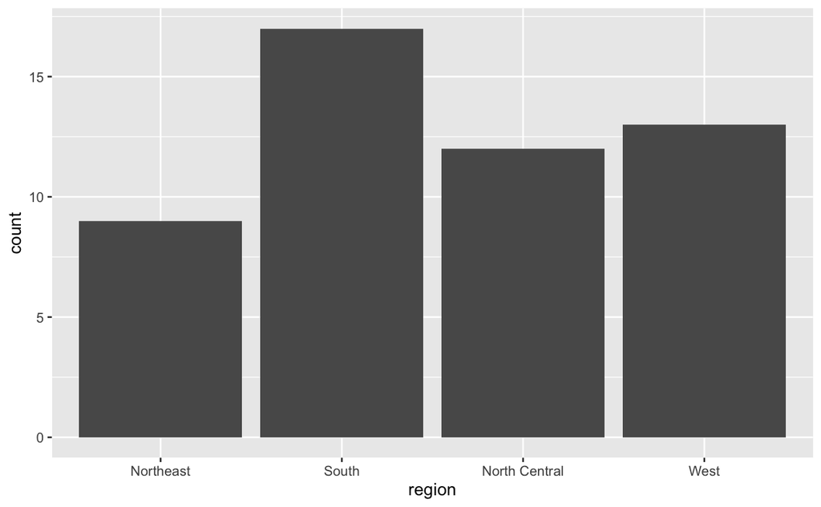

```r
murders %>% ggplot(aes(region)) +
  geom_bar()
```

We often already have a table with a distribution that we want to present as a barplot. Here is an example of such a table:

```r
data(murders)
tab <- murders %>%
  count(region) %>%
  mutate(proportion=n/sum(n))
tab
```

| region | n | proportion |
| --- | --- | --- |
| Northeast | 9 | 0.1764706 |
| South | 17 | 0.3333333 |
| North Central | 12 | 0.2352941 |
| West | 13 | 0.2549020 |

We no longer want `geom_bar` to count, but rather just plot a bar to the height provided by the `proportion` variable. For this we need to provide `x` (the categories) and `y` (the values) and use the `stat="identity"` option.

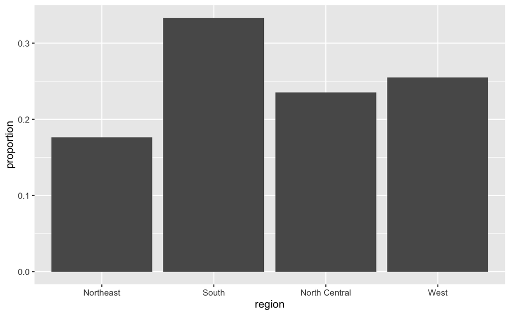

```r
tab %>% ggplot(aes(region,proportion)) + geom_bar(stat='identity')
```

### **8.16.2 Histograms**

To generate histograms we use `geom_histogram`. By looking at the help file for this function, we learn that the only required argument is `x`, the variable for which we will construct a histogram. We dropped the `x` because we know it is the first argument. The code looks like this:

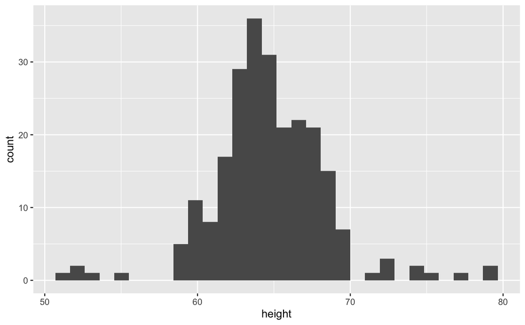

```r
heights %>%
  filter(sex=='Female') %>%
  ggplot(aes(height)) +
  geom_histogram()
```

If we run the code above, it gives us a message:

```r
stat_bin() using bins = 30. Pick better value with binwidth.
```

We previously used a bin size of 1 inch, so the code looks like this:

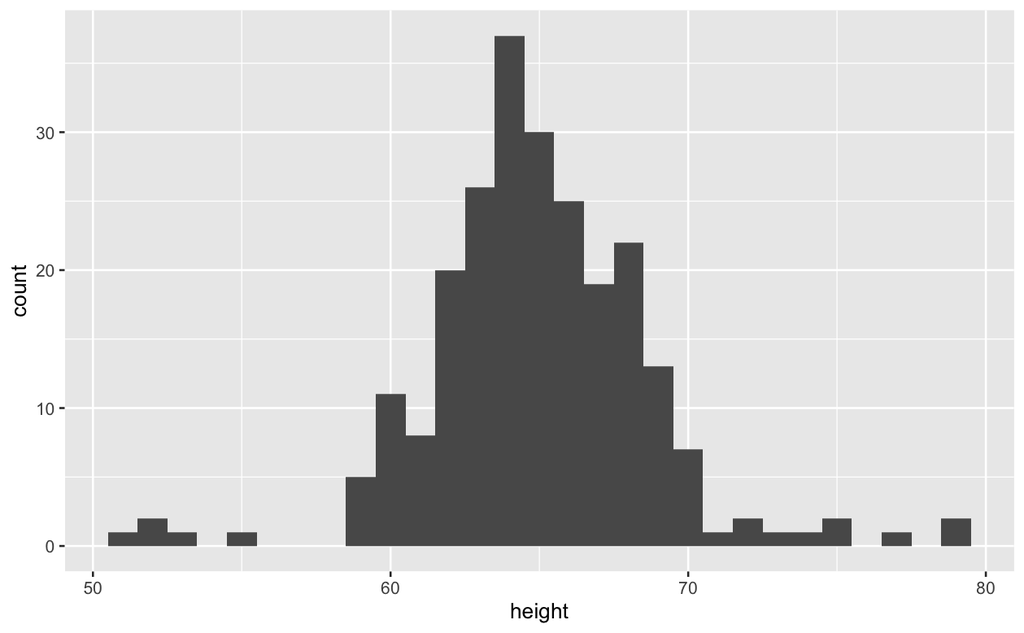

```r
heights %>%
  filter(sex == 'Female') %>%
  ggplot(aes(height)) +
  geom_histogram(binwidth = 1)
```

Finally, if for aesthetic reasons we want to add color, we use the arguments described in the help file. We also add labels and a title:

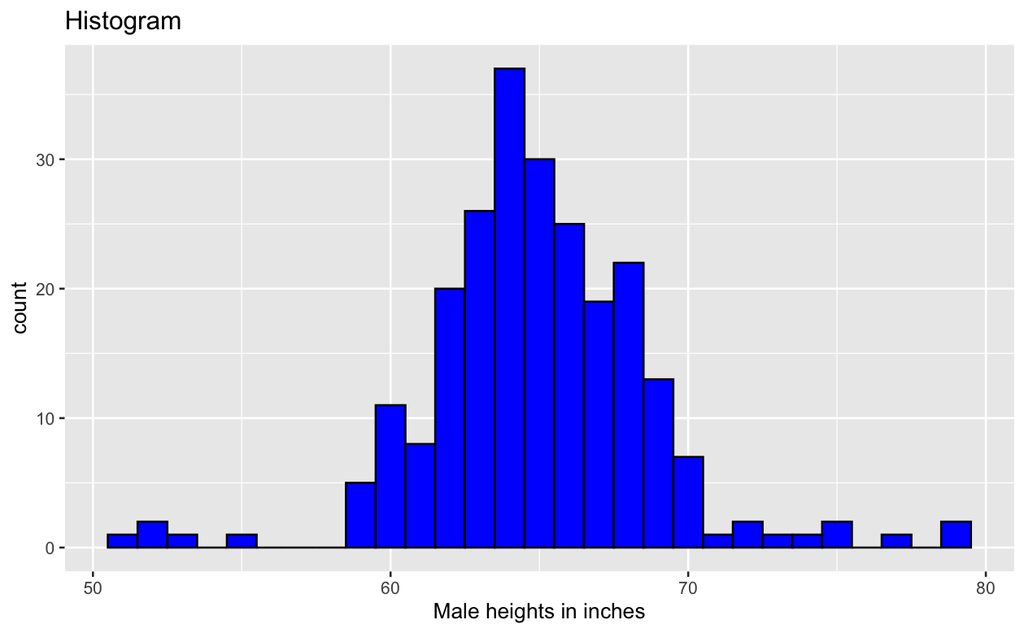

```r
heights %>%
  filter(sex=='Female') %>%
  ggplot(aes(height)) +
  geom_histogram(binwidth=1,fill='blue',col='black') +
  xlab('Male heights in inches') +
  ggtitle("Histogram")
```

### **8.16.3 Density plots**

To create a smooth density, we use the `geom_density`. To make a smooth density plot with the data previously shown as a histogram we can use this code:

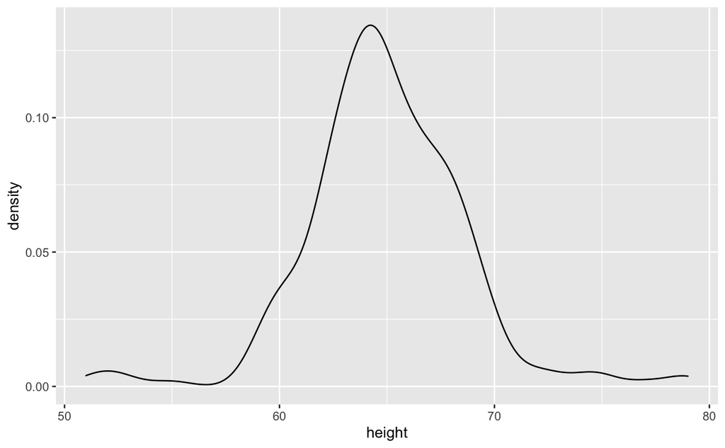

```r
heights %>% filter(sex=="Female") %>%
  ggplot(aes(height)) +
  geom_density()
```

To fill in with color, we can use the `fill` argument.

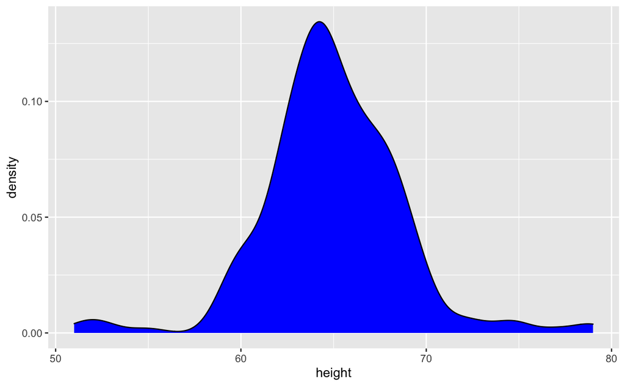

```r
heights %>%
  filter(sex=="Female") %>%
  ggplot(aes(height)) +
  geom_density(fill="blue")
```

To change the smoothness of the density, we use the `adjust` argument to multiply the default value by that `adjust`. For example, if we want the bandwidth to be twice as big we use:

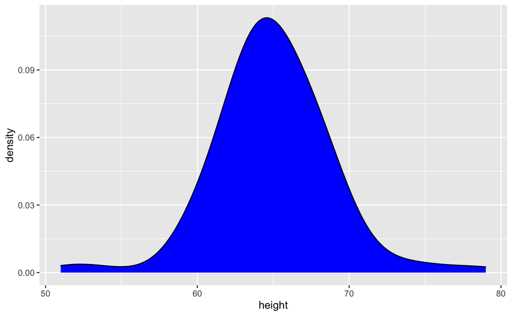

```r
heights %>%
  filter(sex=="Female") %>%
  ggplot(aes(height)) +
  geom_density(fill="blue", adjust = 2)
```

### **8.16.4 Boxplots**

The geometry for boxplot is `geom_boxplot`. As discussed, boxplots are useful for comparing distributions. For example, below are the previously shown heights for women, but compared to men. For this geometry, we need arguments `x` as the categories, and `y` as the values.

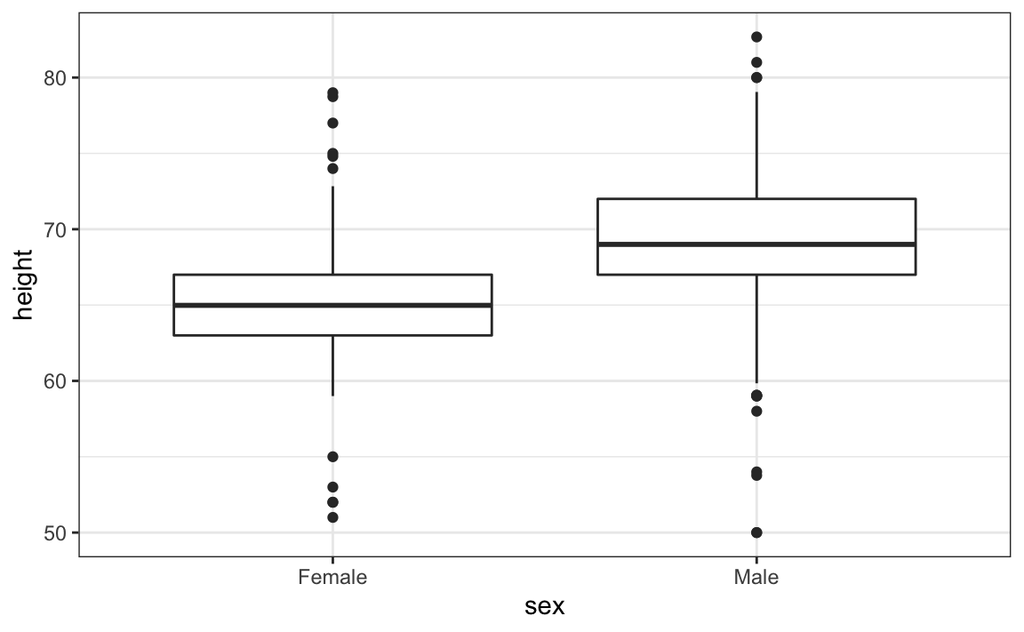

### **8.16.5 QQ-plots**

For qq-plots we use the `geom_qq` geometry. From the help file, we learn that we need to specify the `sample` (we will learn about samples in a later chapter). Here is the qqplot for men heights.

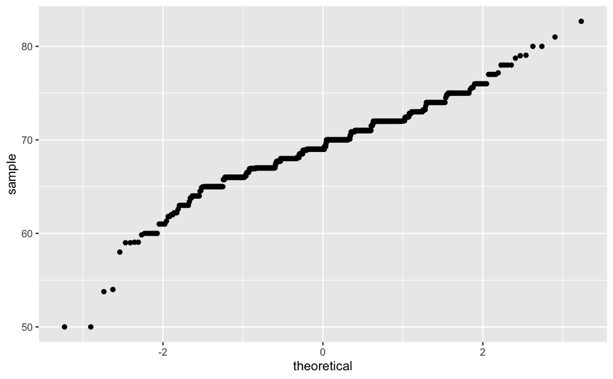

```r
heights %>% filter(sex=="Male") %>%
  ggplot(aes(sample=height)) +
  geom_qq()
```

By default, the sample variable is compared to a normal distribution with average 0 and standard deviation 1. To change this, we use the `dparams` arguments based on the help file. Adding an identity line is as simple as assigning another layer. For straight lines, we use the `geom_abline` function. The default line is the identity line (slope = 1, intercept = 0).

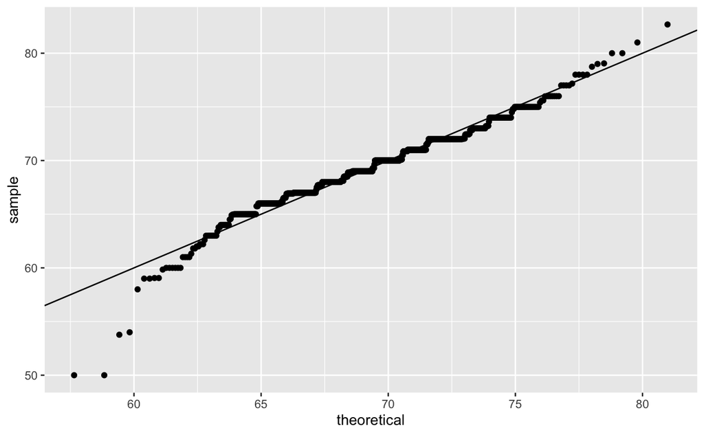

```r
params <- heights %>% filter(sex=="Male") %>%
  summarize(mean=mean(height),sd=sd(height))
heights %>% filter(sex=="Male") %>%
  ggplot(aes(sample=height)) +
  geom_qq(dparams=params) +
  geom_abline()
```

Another option here is to scale the data first and then make a qqplot against the standard normal.

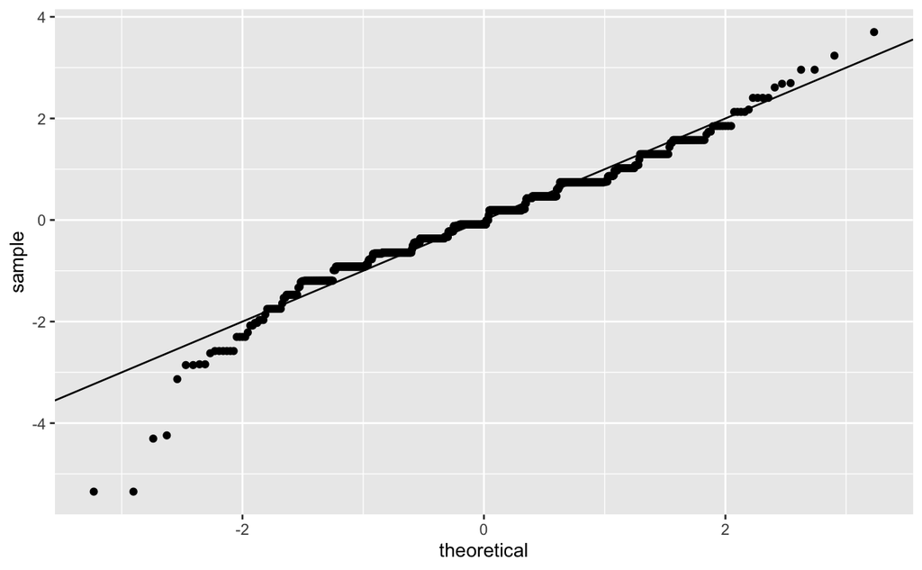

```r
heights %>%
  filter(sex=="Male") %>%
  ggplot(aes(sample=scale(height))) +
  geom_qq() +
  geom_abline()
```

### **8.16.6 Images**

Images were not needed for the concepts described in this chapter, but we will use images in Section 10.14, so we introduce the two geometries used to create images: **geom_tile** and **geom_raster**. They behave similarly; to see how they differ, please consult the help file. To create an image in **ggplot2** we need a data frame with the x and y coordinates as well as the values associated with each of these. Here is a data frame.

```r
x <- expand.grid(x=1:12, y = 1:10) %>%
  mutate(z=1:120)
```

Note that this is the tidy version of a matrix, `matrix(1:120, 12, 10)`. To plot the image we use the following code:

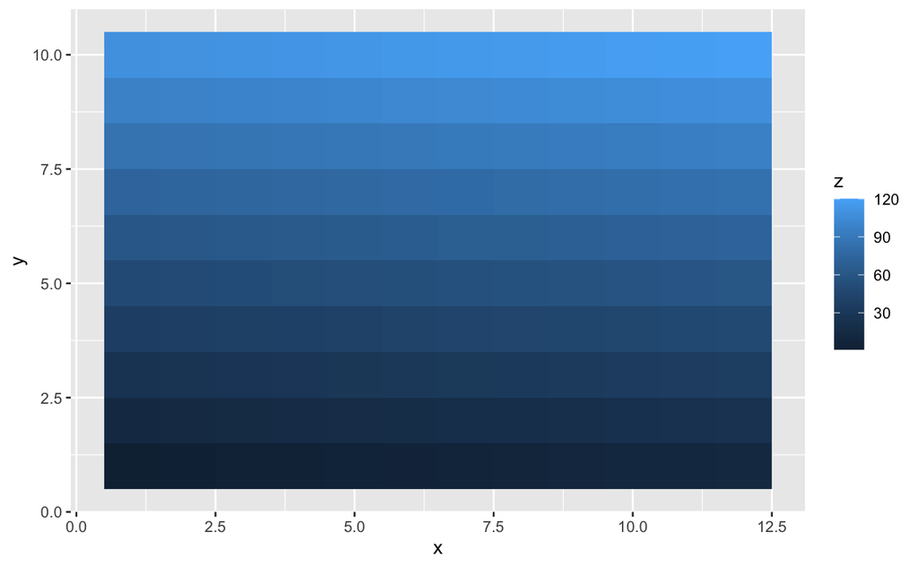

```r
x %>% ggplot(aes(x,y,fill=z)) +
  geom_raster()
```

With these images you will often want to change the color scale. This can be done through the `scale_fill_gradientn` layer.

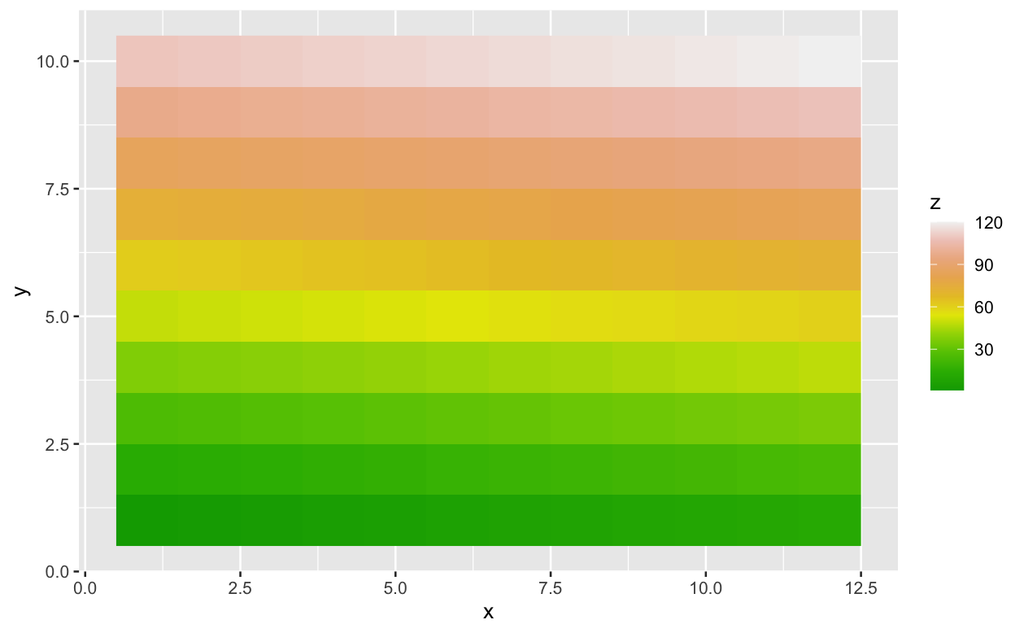

```r
x %>% ggplot(aes(x,y,fill=z)) +
  geom_raster() +
  scale_fill_gradientn(colors = terrain.colors(10))
```

### **8.16.7 Quick plots**

In Section 7.13 we introduced `qplot` as a useful function when we need to make a quick scatterplot. We can also use `qplot` to make histograms, density plots, boxplot, qqplots and more. Although it does not provide the level of control of `ggplot`, `qplot` is definitely useful as it permits us to make a plot with a short snippet of code.

```r
x <- heights %>%
  filter(sex=="Male") %>%
  pull(height)
```

To make a quick histogram we can use:

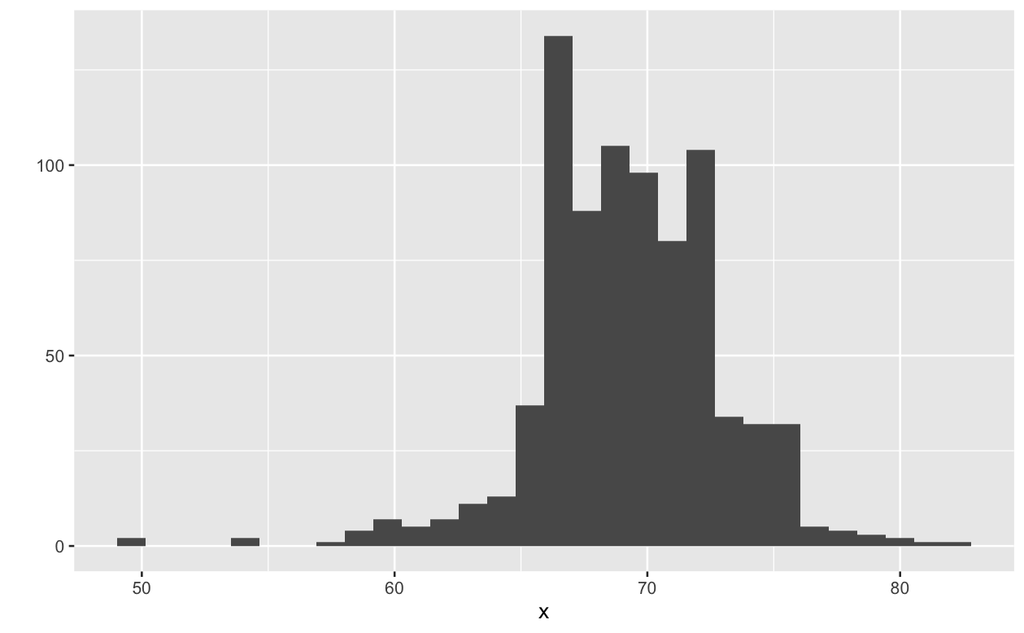

```r
qplot(x)
```

The function guesses that we want to make a histogram because we only supplied one variable. In Section 7.13 we saw that if we supply `qplot` two variables, it automatically makes a scatterplot.

To make a quick qqplot you have to use the `sample` argument. Note that we can add layers just as we do with `ggplot`.

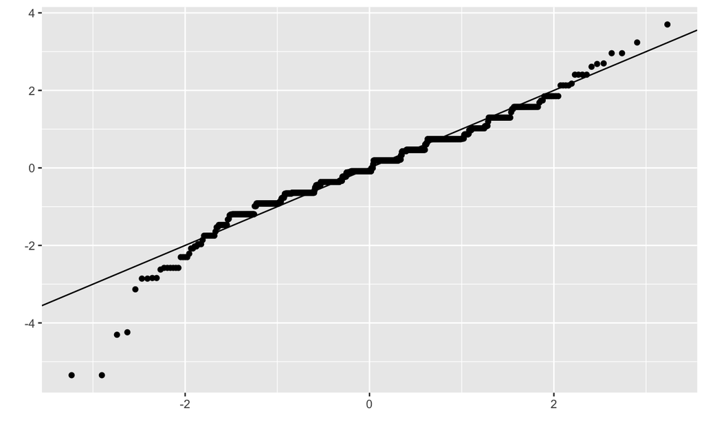

```r
qplot(sample=scale(x)) + geom_abline()
```

If we supply a factor and a numeric vector, we obtain a plot like the one below. Note that in the code below we are using the `data` argument. Because the data frame is not the first argument in `qplot`, we have to use the dot operator.

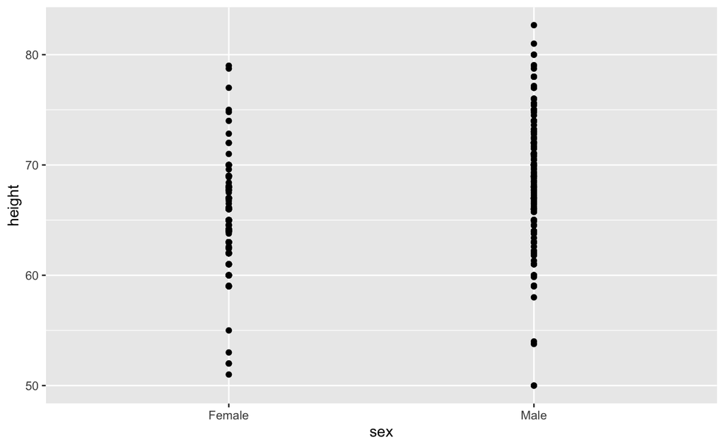

```r
heights %>% qplot(sex,height,data=.)
```

We can also select a specific geometry by using the `geom` argument. So to convert the plot above to a boxplot, we use the following code:

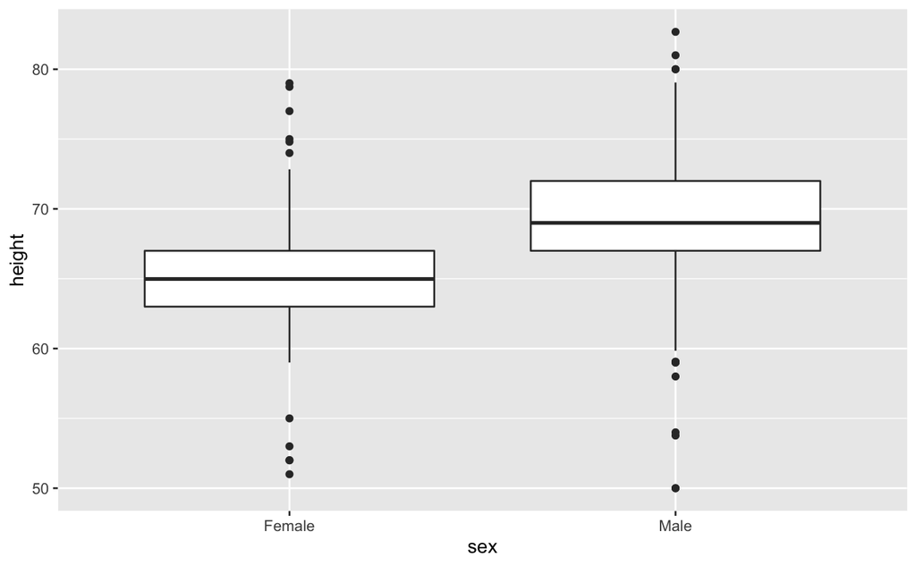

```r
heights %>% qplot(sex, height, data=., geom="boxplot")
```

We can also use the `geom` argument to generate a density plot instead of a histogram:

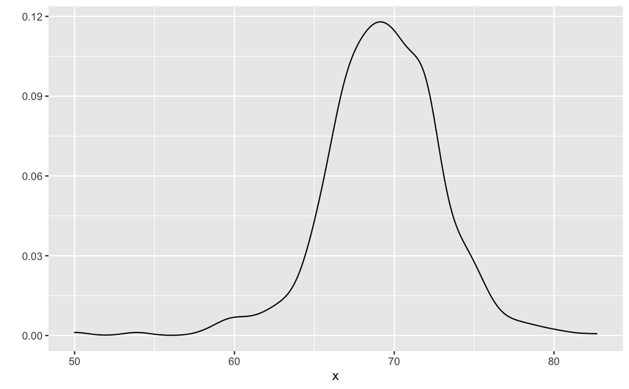

```r
qplot(x, geom="density")
```

Although not as much as with `ggplot`, we do have some flexibility to improve the results of `qplot`. Looking at the help file we see several ways in which we can improve the look of the histogram above. Here is an example:

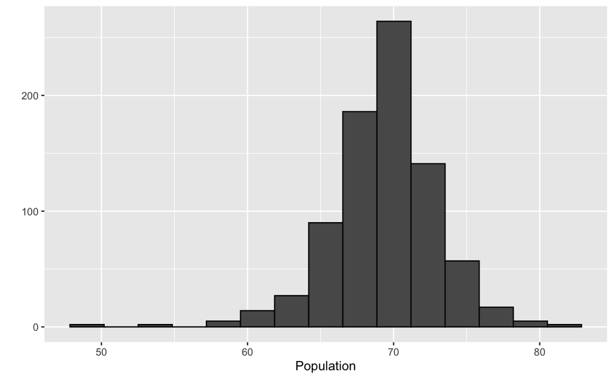

```r
qplot(x, bins=15, color=I("black"),xlab="Population")
```

**Technical note**: The reason we use `I("black")` is because we want `qplot` to treat `"black"` as a character rather than convert it to a factor, which is the default behavior within `aes`, which is internally called here. In general, the function `I` is used in R to say “keep it as it is”.

## **8.17 Exercises**

1.Now we are going to use the `geom_histogram` function to make a histogram of the heights in the `height` data frame. When reading the documentation for this function we see that it requires just one mapping, the values to be used for the histogram. Make a histogram of all the plots.

What is the variable containing the heights?

1. `sex`
2. `heights`
3. `height`
4. `heights$height`

```r
#The answer is 'c'.
```

2.Now create a ggplot object using the pipe to assign the heights data to a ggplot object. Assign `height` to the x values through the `aes` function.

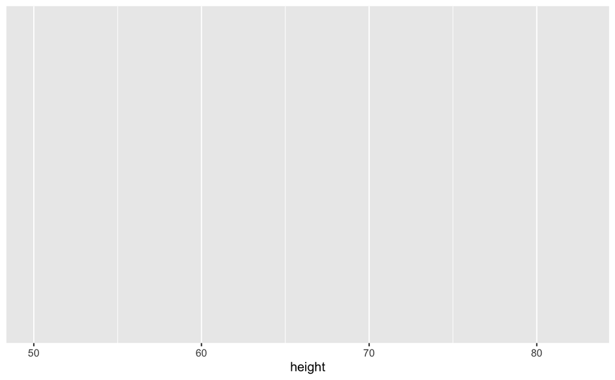

```r
heights %>% ggplot(aes(height))
```

3.Now we are ready to add a layer to actually make the histogram. Use the object created in the previous exercise and the `geom_histogram` function to make the histogram.

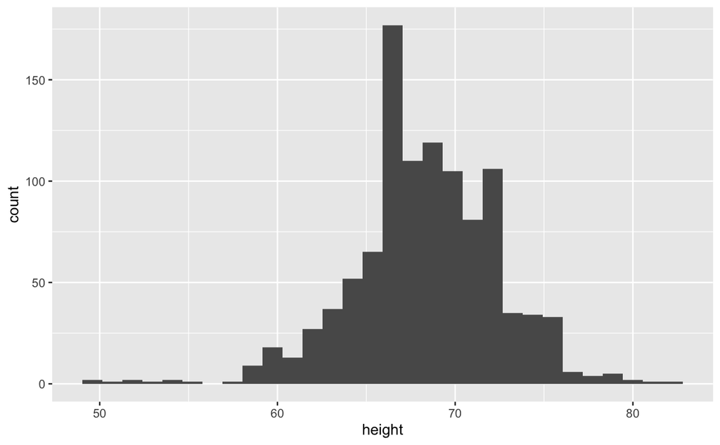

```r
heights %>% ggplot(aes(height)) + geom_histogram()
```

4.Note that when we run the code in the previous exercise we get the warning: `stat_bin()` using `bins = 30`. Pick better value with `binwidth.`

Use the `binwidth` argument to change the histogram made in the previous exercise to use bins of size 1 inch.

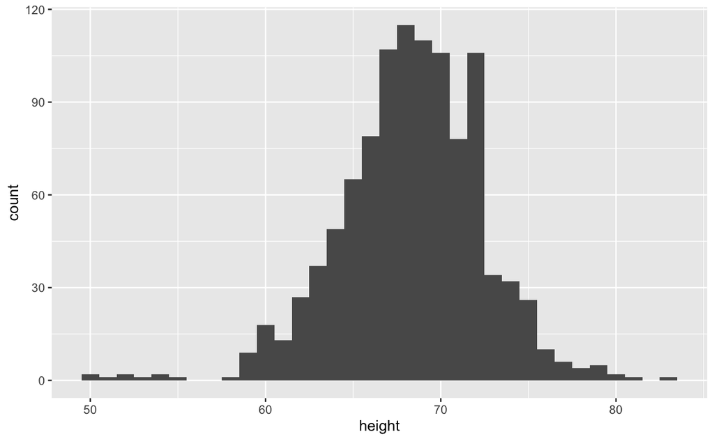

```r
heights %>% ggplot(aes(height)) +
  geom_histogram(binwidth = 1)
```

5.Instead of a histogram, we are going to make a smooth density plot. In this case we will not make an object, but instead render the plot with one line of code. Change the geometry in the code previously used to make a smooth density instead of a histogram.

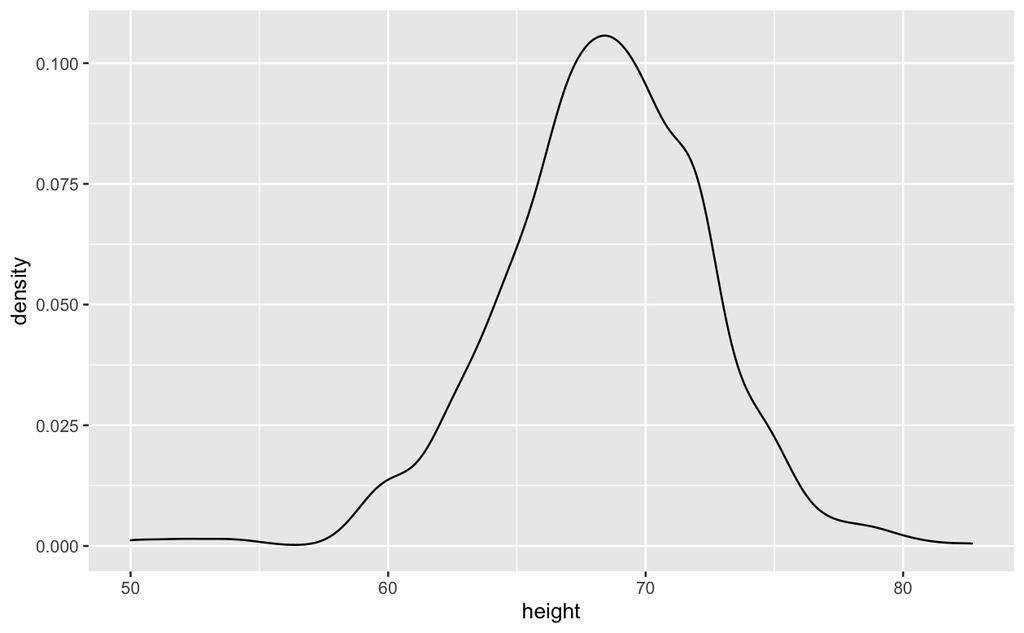

```r
heights %>% ggplot(aes(height)) + geom_density()
```

6. Now we are going to make a density plot for males and females separately. We can do this using the `group` argument. We assign groups via the aesthetic mapping as each point needs to a group before making the calculations needed to estimate a density.

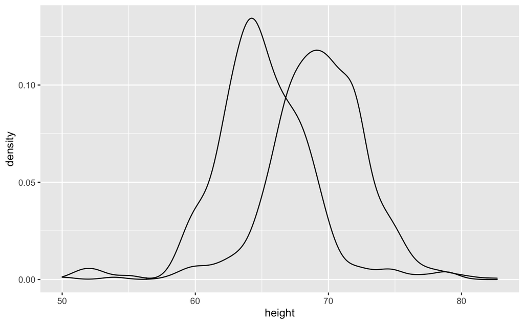

```r
heights %>% ggplot(aes(height, group=sex)) + geom_density()
```

7. We can also assign groups through the `color` argument. This has the added benefit that it uses color to distinguish the groups. Change the code above to use color.

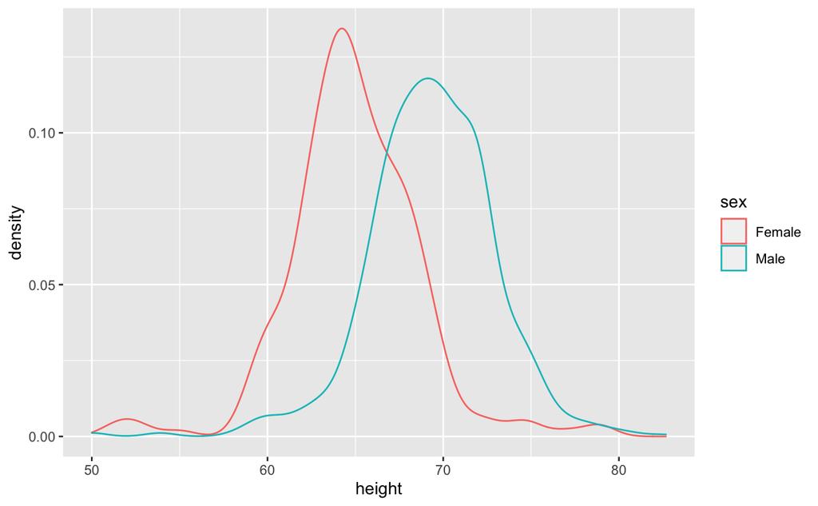

```r
heights %>% ggplot(aes(height,group=sex,color=sex)) + geom_density()
```

8. We can also assign groups through the `fill` argument. This has the added benefit that it uses colors to distinguish the groups, like this:

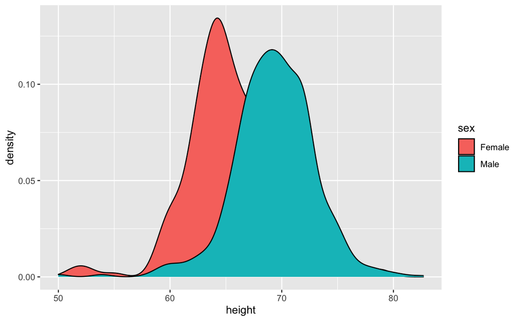

```r
heights %>%
  ggplot(aes(height, fill=sex)) +
  geom_density()
```

However, here the second density is drawn over the other. We can make the curves more visible by using alpha blending to add transparency. Set the alpha parameter to 0.2 in the `geom_density` function to make this change.

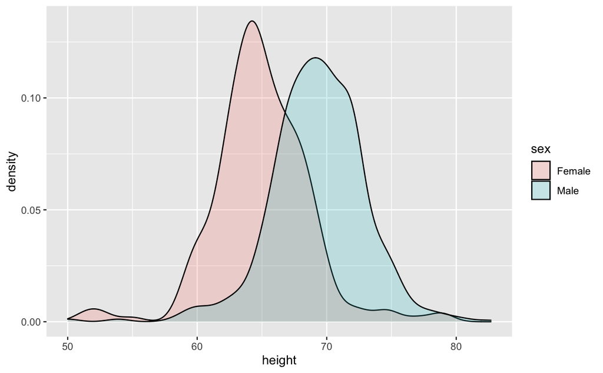

```r
heights %>% ggplot(aes(height, fill=sex)) +
  geom_density(alpha=0.2)
```